# 3.7 — Regression with Interaction Effects — R Practice

Answers

ECON 480 — Econometrics — Fall 2021

## Question 1

We are returning to the speeding tickets data that we began to explore in [R Practice 3.4 on Multivariate Regression](http://metricsf21.classes.ryansafner.com/r/3.4-r-practice). Download and read in (`read_csv`) the data below.

- [`speeding_tickets.csv`](http://metricsf21.classes.ryansafner.com/data/speeding_tickets.csv)

This data again comes from a paper by Makowsky and Strattman (2009). Even though state law sets a formula for tickets based on how fast a person was driving, police officers in practice often deviate from that formula. This dataset includes information on all traffic stops. An amount for the fine is given only for observations in which the police officer decided to assess a fine. There are a number of variables in this dataset, but the one’s we’ll look at are:

| Variable | Description |
| --- | --- |
| `Amount` | Amount of fine (in dollars) assessed for speeding |
| `Age` | Age of speeding driver (in years) |
| `MPHover` | Miles per hour over the speed limit |
| `Black` | Dummy $=1$ if driver was black, $=0$ if not |
| `Hispanic` | Dummy $=1$ if driver was Hispanic, $=0$ if not |
| `Female` | Dummy $=1$ if driver was female, $=0$ if not |
| `OutTown` | Dummy $=1$ if driver was not from local town, $=0$ if not |
| `OutState` | Dummy $=1$ if driver was not from local state, $=0$ if not |
| `StatePol` | Dummy $=1$ if driver was stopped by State Police, $=0$ if stopped by other (local) |

> We again want to explore who gets fines, and how much.

```r
library(tidyverse)
speed <- read_csv("http://metricsf21.classes.ryansafner.com/Data/speeding_tickets.csv")
```

## Question 2

We will have to do a little more cleaning to get some of the data into a more usable form.

### Part A

Inspect the data with `str()` or `head()` or `glimpse()` to see what it looks like.

```r
str(speed)
```

```
## spec_tbl_df [68,357 × 9] (S3: spec_tbl_df/tbl_df/tbl/data.frame)
##  $ Black   : num [1:68357] 0 0 0 0 0 0 0 0 0 0 ...
##  $ Hispanic: num [1:68357] 0 0 0 0 0 0 0 0 0 0 ...
##  $ Female  : num [1:68357] 1 1 1 0 0 0 1 0 1 0 ...
##  $ Amount  : num [1:68357] NA NA NA NA NA NA NA NA NA NA ...
##  $ MPHover : num [1:68357] 14 15 15 13 12 17 15 15 15 15 ...
##  $ Age     : num [1:68357] 22 43 32 24 54 30 18 53 51 33 ...
##  $ OutTown : num [1:68357] 1 1 0 1 1 1 0 0 1 1 ...
##  $ OutState: num [1:68357] 0 0 0 0 0 0 0 0 0 0 ...
##  $ StatePol: num [1:68357] 0 0 0 0 0 0 0 0 0 0 ...
##  - attr(*, "spec")=
##   .. cols(
##   ..   Black = col_double(),
##   ..   Hispanic = col_double(),
##   ..   Female = col_double(),
##   ..   Amount = col_double(),
##   ..   MPHover = col_double(),
##   ..   Age = col_double(),
##   ..   OutTown = col_double(),
##   ..   OutState = col_double(),
##   ..   StatePol = col_double()
##   .. )
##  - attr(*, "problems")=<externalptr>
```

```r
head(speed)
```

| Black | Hispanic | Female | Amount | MPHover | Age | OutTown | OutState | StatePol |
| --- | --- | --- | --- | --- | --- | --- | --- | --- |
| 0 | 0 | 1 | NA | 14 | 22 | 1 | 0 | 0 |
| 0 | 0 | 1 | NA | 15 | 43 | 1 | 0 | 0 |
| 0 | 0 | 1 | NA | 15 | 32 | 0 | 0 | 0 |
| 0 | 0 | 0 | NA | 13 | 24 | 1 | 0 | 0 |
| 0 | 0 | 0 | NA | 12 | 54 | 1 | 0 | 0 |
| 0 | 0 | 0 | NA | 17 | 30 | 1 | 0 | 0 |

```r
glimpse(speed)
```

```
## Rows: 68,357
## Columns: 9
## $ Black    <dbl> 0, 0, 0, 0, 0, 0, 0, 0, 0, 0, 0, 0, 0, 0, 0, 0, 0, 0, 0, 0, 0…
## $ Hispanic <dbl> 0, 0, 0, 0, 0, 0, 0, 0, 0, 0, 0, 0, 0, 0, 0, 0, 0, 0, 0, 0, 0…
## $ Female   <dbl> 1, 1, 1, 0, 0, 0, 1, 0, 1, 0, 0, 0, 1, 1, 1, 0, 0, 0, 0, 1, 0…
## $ Amount   <dbl> NA, NA, NA, NA, NA, NA, NA, NA, NA, NA, NA, NA, NA, NA, NA, N…
## $ MPHover  <dbl> 14, 15, 15, 13, 12, 17, 15, 15, 15, 15, 13, 11, 15, 15, 13, 1…
## $ Age      <dbl> 22, 43, 32, 24, 54, 30, 18, 53, 51, 33, 48, 36, 31, 45, 41, 3…
## $ OutTown  <dbl> 1, 1, 0, 1, 1, 1, 0, 0, 1, 1, 1, 1, 1, 1, 1, 1, 1, 1, 1, 1, 1…
## $ OutState <dbl> 0, 0, 0, 0, 0, 0, 0, 0, 0, 0, 0, 0, 0, 0, 0, 0, 0, 0, 0, 1, 0…
## $ StatePol <dbl> 0, 0, 0, 0, 0, 0, 0, 0, 0, 0, 0, 0, 0, 0, 0, 0, 0, 0, 0, 0, 0…
```

### Part B

What `class` of variable are `Black`, `Hispanic`, `Female`, `OutTown`, and `OutState`?

Hint: use the `class(df$variable)` command to ask what class something is, where `df` is your dataframe, and `variable` is the name of a variable. Alternatively, it should also show the class automatically from the commands from Part A.

Using the above commands, or looking at the data should show you that these variables are `numeric` (`num`). It is also possible `R` may have read them as `integer` (`int`), a special type of `numeric` data that are whole numbers only.

```r
class(speed$Black)
```

```
## [1] "numeric"
```

```r
class(speed$Hispanic)
```

```
## [1] "numeric"
```

```r
class(speed$Female)
```

```
## [1] "numeric"
```

```r
class(speed$OutTown)
```

```
## [1] "numeric"
```

```r
class(speed$OutState)
```

```
## [1] "numeric"
```

### Part C

Notice that when importing the data from the `.csv` file, `R` interpreted these variables as `numeric` (`num`) or `double` (`dbl`), but we want them to be `factor` (`fct`) variables, to ensure `R` recognizes that there are two groups (categories), 0 and 1. Convert each of these variables into factors by reassigning it according to the format:

```r
df <- df %>% # where df is your data
  mutate(my_var = as.factor(my_var) # where my_var is the variable
  )
```

You could do this for each variable, or all at once, using `mutate_at()`:

```r
df <- df %>%
  mutate_at(c("Black", "Hispanic", "Female", "OutTown", "OutState"), factor)
```

Recall the [class on Data Wrangling](https://metricsf21.classes.ryansafner.com/content/1.4-content) for all the mutate possibilities!

```r
speed <- speed %>%
  mutate_at(c("Black", "Hispanic", "Female", "OutTown", "OutState"), factor)
```

### Part D

Confirm they are each now factors by checking their class or looking at the data again.

Again we could just look at the data to verify, but here I check manually each variable:

```r
class(speed$Black)
```

```
## [1] "factor"
```

```r
class(speed$Hispanic)
```

```
## [1] "factor"
```

```r
class(speed$Female)
```

```
## [1] "factor"
```

```r
class(speed$OutTown)
```

```
## [1] "factor"
```

```r
class(speed$OutState)
```

```
## [1] "factor"
```

### Part E

Get a `summary()` of `Amount` using:

```r
df %>% # or whatever your dataframe is called
  select(Amount) %>%
  summary()
```

Note that there are a lot of `NA`’s (these are people that were stopped but did not receive a fine)! Let’s `filter()` to use only those observations for which `Amount` is a positive number, and save this in your dataframe (assign and overwrite it, or make a new dataframe).

```r
df <- df %>% # overwrite or make a new dataframe
  filter(Amount > 0)

# verify it worked
df %>%
  select(Amount) %>%
  summar()
```

```r
# Get summary of Amount to see NAs
speed %>%
  select(Amount) %>%
  summary()
```

```
##      Amount
##  Min.   :  3
##  1st Qu.: 75
##  Median :115
##  Mean   :122
##  3rd Qu.:155
##  Max.   :725
##  NA's   :36683
```

```r
## alternatively, using base R:
summary(speed$Amount)
```

```
##    Min. 1st Qu.  Median    Mean 3rd Qu.    Max.    NA's
##       3      75     115     122     155     725   36683
```

```r
# keep only positive Amount
speed <- speed %>% # overwrite speed
  filter(Amount > 0)

# check new data
speed %>%
  select(Amount) %>%
  summary()
```

```
##      Amount
##  Min.   :  3
##  1st Qu.: 75
##  Median :115
##  Mean   :122
##  3rd Qu.:155
##  Max.   :725
```

## Question 3

Create a scatterplot between `Amount` (as `y`) and Female (as `x`).

Hint: Use `geom_jitter()` instead of `geom_point()` to plot the points, and play around with `width` settings inside `geom_jitter()`

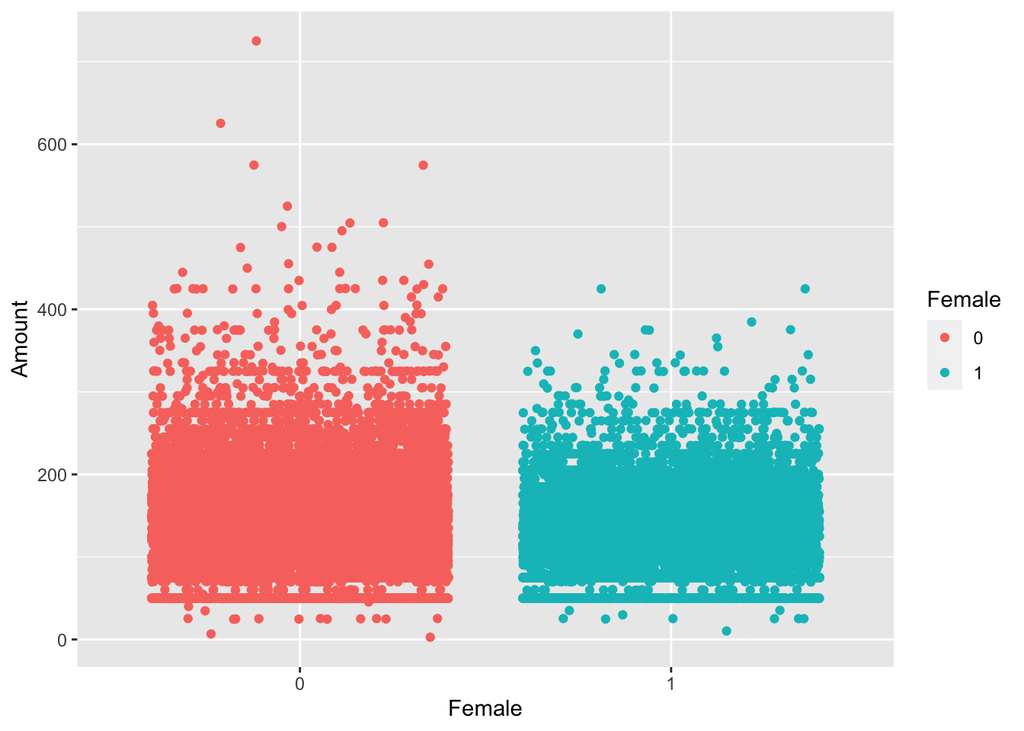

```r
ggplot(data = speed)+
  aes(x = Female,
      y = Amount,
      color = Female)+
  geom_jitter(width = 0.4)
```

Note if you had not made `Female` a `factor`, and kept it numeric, it might alter the plot.

You can make `Female` a `factor` just for plotting by setting `aes(x = as.factor(Female))` inside the `aes()` layer.

## Question 4

Now let’s start looking at the distribution conditionally to find the different group means.

### Part A

Find the mean and standard deviation of `Amount` for *male* drivers and again for *female* drivers.

Hint: properly `filter()` the data and then use the `summarize()` command.

```r
# Summarize for Men

# I'll save as male_summary, since
# we'll use this in next part

male_summary <- speed %>%
  filter(Female == 0) %>%
  summarize(mean = mean(Amount),
            sd = sd(Amount))

# look at it
male_summary
```

| mean | sd |
| --- | --- |
| 124.6654 | 58.28387 |

```r
# Summarize for Women

# I'll save as female_summary, since
# we'll use this in next part

female_summary <- speed %>%
  filter(Female == 1) %>%
  summarize(mean = mean(Amount),
            sd = sd(Amount))

# look at it
female_summary
```

| mean | sd |
| --- | --- |
| 116.726 | 51.48665 |

### Part B

What is the difference between the average Amount for Males and Females?

```r
# we can do this with R using our summary dataframes we made last part

male_avg <- male_summary %>%
  pull(mean) # pull extracts the value

male_avg #check
```

```
## [1] 124.6654
```

```r
female_avg <- female_summary %>%
  pull(mean)

female_avg #check
```

```
## [1] 116.726
```

```r
# difference
male_avg - female_avg
```

```
## [1] 7.939397
```

Males get $ 124.67 and Females get $ 116.73, so Males get $ 7.94 higher fines on average than Females.

### Part C

We did not go over how to do this in class, but you can run a **t-test for the difference in group means** to see if the difference is statistically significant. The syntax is similar for a regression:

```r
t.test(Amount ~ Female,
       data = df)
```

Is there a statistically significant difference between `Amount` for male and female drivers? Hint: this is like any hypothesis test. Here $H_0: \text{difference}=0$. A $t$-value needs to be large enough to be greater than a critical value of $t$. Check the $p$-value and see if it is less than our standard of $\alpha=0.05.$

```r
t.test(Amount ~ Female, data = speed)
```

```
##
##  Welch Two Sample t-test
##
## data:  Amount by Female
## t = 12.356, df = 23400, p-value < 2.2e-16
## alternative hypothesis: true difference in means between group 0 and group 1 is not equal to 0
## 95 percent confidence interval:
##  6.679941 9.198853
## sample estimates:
## mean in group 0 mean in group 1
##        124.6654        116.7260
```

## Question 5

Now run the following regression to ensure we get the same result as the t-test.

$$\text{Amount}_i=\hat{\beta_0}+\hat{\beta_1}Female_i$$

```r
female_reg <- lm(Amount ~ Female, data = speed)
summary(female_reg)
```

```
##
## Call:
## lm(formula = Amount ~ Female, data = speed)
##
## Residuals:
##     Min      1Q  Median      3Q     Max
## -121.67  -49.67   -6.73   30.33  600.33
##
## Coefficients:
##             Estimate Std. Error t value Pr(>|t|)
## (Intercept) 124.6654     0.3857  323.23   <2e-16 ***
## Female1      -7.9394     0.6698  -11.85   <2e-16 ***
## ---
## Signif. codes:  0 '***' 0.001 '**' 0.01 '*' 0.05 '.' 0.1 ' ' 1
##
## Residual standard error: 56.12 on 31672 degrees of freedom
## Multiple R-squared:  0.004416,   Adjusted R-squared:  0.004385
## F-statistic: 140.5 on 1 and 31672 DF,  p-value: < 2.2e-16
```

```r
# can also do broom's tidy()
library(broom)
tidy(female_reg)
```

| term | estimate | std.error | statistic | p.value |
| --- | --- | --- | --- | --- |
| (Intercept) | 124.665423 | 0.3856913 | 323.22592 | 0.000000e+00 |
| Female1 | -7.939397 | 0.6698475 | -11.85254 | 2.443741e-32 |

### Part A

Write out the estimated regression equation.

$$\widehat{\text{Amount}_i}=124.67-7.94\text{Female}_i$$

```r
# PUT CODE HERE
```

### Part B

Use the regression coefficients to find

```r
# PUT CODE HERE
```

## Question 6

Let’s recode the sex variable to `Male` instead of `Female`.

### Part A

Make a new variable called `Male` and save it in your dataframe using the `ifelse()` command:

```r
df <- df %>% # overwrite or save as another dataframe
  mutate(Male = ifelse(Female == 0, # test observation to see if Female is 0
                       yes = 1, # if yes (a Male), code Male as 1
                       no  = 0), # if no (a Female), code Male as 0
         )

# Verify it worked
df %>%
  select(Female, Male)
```

```r
speed <- speed %>% # overwrite or save as another dataframe
  mutate(Male = ifelse(Female == 0, # test observation to see if Female is 0
                       yes = 1, # if yes (a Male), code Male as 1
                       no  = 0), # if no (a Female), code Male as 0
         )

# Verify it worked
speed %>%
  select(Female, Male)
```

| Female | Male |
| --- | --- |
| 0 | 1 |
| 0 | 1 |
| 0 | 1 |
| 1 | 0 |
| 0 | 1 |
| 0 | 1 |
| 1 | 0 |
| 1 | 0 |
| 0 | 1 |
| 1 | 0 |

[output cut: 9990 more lines]

### Part B

Run the same regression as in question 5, but use `Male` instead of `Female`.

```r
male_reg <- lm(Amount ~ Male, data = speed)
summary(male_reg)
```

```
##
## Call:
## lm(formula = Amount ~ Male, data = speed)
##
## Residuals:
##     Min      1Q  Median      3Q     Max
## -121.67  -49.67   -6.73   30.33  600.33
##
## Coefficients:
##             Estimate Std. Error t value Pr(>|t|)
## (Intercept) 116.7260     0.5477  213.13   <2e-16 ***
## Male          7.9394     0.6698   11.85   <2e-16 ***
## ---
## Signif. codes:  0 '***' 0.001 '**' 0.01 '*' 0.05 '.' 0.1 ' ' 1
##
## Residual standard error: 56.12 on 31672 degrees of freedom
## Multiple R-squared:  0.004416,   Adjusted R-squared:  0.004385
## F-statistic: 140.5 on 1 and 31672 DF,  p-value: < 2.2e-16
```

```r
tidy(male_reg)
```

| term | estimate | std.error | statistic | p.value |
| --- | --- | --- | --- | --- |
| (Intercept) | 116.726026 | 0.5476659 | 213.13363 | 0.000000e+00 |
| Male | 7.939397 | 0.6698475 | 11.85254 | 2.443741e-32 |

### Part C

Write out the estimated regression equation.

$$\widehat{Amount}_i = 116.73+7.94Male_i$$

```r
# PUT CODE HERE
```

### Part D

Use the regression coefficients to find

```r
# PUT CODE HERE
```

## Question 7

Run a regression of `Amount` on `Male` and `Female`. What happens, and why?

```r
dummy_variable_trap <- lm(Amount ~ Male + Female, data = speed)
summary(dummy_variable_trap)
```

```
##
## Call:
## lm(formula = Amount ~ Male + Female, data = speed)
##
## Residuals:
##     Min      1Q  Median      3Q     Max
## -121.67  -49.67   -6.73   30.33  600.33
##
## Coefficients: (1 not defined because of singularities)
##             Estimate Std. Error t value Pr(>|t|)
## (Intercept) 116.7260     0.5477  213.13   <2e-16 ***
## Male          7.9394     0.6698   11.85   <2e-16 ***
## Female1           NA         NA      NA       NA
## ---
## Signif. codes:  0 '***' 0.001 '**' 0.01 '*' 0.05 '.' 0.1 ' ' 1
##
## Residual standard error: 56.12 on 31672 degrees of freedom
## Multiple R-squared:  0.004416,   Adjusted R-squared:  0.004385
## F-statistic: 140.5 on 1 and 31672 DF,  p-value: < 2.2e-16
```

`Male` and `Female` are perfectly multicollinear, as for every person $i$, `Male`$_i$+`Female`$_i$=1. We can confirm this by seeing the correlation between `Male` and `Female` is exactly $-1$. To run a regression, we must exclude one of the dummies, and as we’ve seen, it makes no difference which one we exclude.

```r
speed %>%
  select(Male, Female) %>%
  mutate_if(is.factor, as.numeric) %>% # make both factors into numeric
  cor() # correlation requires numeric data, can't have factors
```

```
##        Male Female
## Male      1     -1
## Female   -1      1
```

## Question 8

`Age` probably has a lot to do with differences in fines, perhaps also age affects fines differences between males and females.

### Part A

Run a regression of `Amount` on `Age` and `Female.` How does the coefficient on `Female` change?

```r
age_reg <- lm(Amount ~ Age + Female, data = speed)
summary(age_reg)
```

```
##
## Call:
## lm(formula = Amount ~ Age + Female, data = speed)
##
## Residuals:
##     Min      1Q  Median      3Q     Max
## -125.77  -45.63   -5.91   33.67  597.66
##
## Coefficients:
##              Estimate Std. Error t value Pr(>|t|)
## (Intercept) 134.19965    0.90969  147.52   <2e-16 ***
## Age          -0.28598    0.02472  -11.57   <2e-16 ***
## Female1      -7.85172    0.66849  -11.74   <2e-16 ***
## ---
## Signif. codes:  0 '***' 0.001 '**' 0.01 '*' 0.05 '.' 0.1 ' ' 1
##
## Residual standard error: 56 on 31671 degrees of freedom
## Multiple R-squared:  0.008604,   Adjusted R-squared:  0.008542
## F-statistic: 137.4 on 2 and 31671 DF,  p-value: < 2.2e-16
```

```r
tidy(age_reg)
```

| term | estimate | std.error | statistic | p.value |
| --- | --- | --- | --- | --- |
| (Intercept) | 134.1996506 | 0.90969259 | 147.52198 | 0.000000e+00 |
| Age | -0.2859785 | 0.02472361 | -11.56702 | 6.985839e-31 |
| Female1 | -7.8517192 | 0.66849063 | -11.74544 | 8.676153e-32 |

The coefficient on `Female` goes from $-7.94$ (question 5) to $-7.85$ when controlling for `Age`.

### Part B

Now let’s see if the difference in fine between men and women are different depending on the driver’s age. Run the regression again, but add an **interaction term** between `Female` and `Age`, using `Female*Age` or `Female:Age`.

```r
# note you can also do Age*Female for the interaction term

interact_reg <- lm(Amount ~ Age + Female + Age:Female, data = speed)
summary(interact_reg)
```

```
##
## Call:
## lm(formula = Amount ~ Age + Female + Age:Female, data = speed)
##
## Residuals:
##     Min      1Q  Median      3Q     Max
## -126.35  -44.68   -5.49   33.49  597.29
##
## Coefficients:
##              Estimate Std. Error t value Pr(>|t|)
## (Intercept) 135.54592    1.07428 126.173  < 2e-16 ***
## Age          -0.32636    0.03008 -10.848  < 2e-16 ***
## Female1     -12.02331    1.89296  -6.352 2.16e-10 ***
## Age:Female1   0.12435    0.05279   2.355   0.0185 *
## ---
## Signif. codes:  0 '***' 0.001 '**' 0.01 '*' 0.05 '.' 0.1 ' ' 1
##
## Residual standard error: 56 on 31670 degrees of freedom
## Multiple R-squared:  0.008778,   Adjusted R-squared:  0.008684
## F-statistic: 93.49 on 3 and 31670 DF,  p-value: < 2.2e-16
```

```r
tidy(interact_reg)
```

| term | estimate | std.error | statistic | p.value |
| --- | --- | --- | --- | --- |
| (Intercept) | 135.5459174 | 1.07428490 | 126.173158 | 0.000000e+00 |
| Age | -0.3263597 | 0.03008437 | -10.848147 | 2.273784e-27 |
| Female1 | -12.0233093 | 1.89296463 | -6.351576 | 2.160090e-10 |
| Age:Female1 | 0.1243543 | 0.05279367 | 2.355478 | 1.850497e-02 |

### Part C

Write out your estimated regression equation.

$$\widehat{\text{Amount}_i}=135.55-12.02\, \text{Female}_i-0.33\, \text{Age}_i+0.12 \, (\text{Female}_i \times \text{Age}_i)$$

```r
# PUT CODE HERE
```

### Part D

Interpret the interaction effect. Is it statistically significant?

The coefficient on the interaction term, $\hat{\beta_3}$ is 0.12. For every additional year of age, females can expect their fine to increase by $0.12 *more* than males gain for every additional year of age.

```r
# PUT CODE HERE
```

### Part E

Plugging in 0 or 1 as necessary, rewrite (on your paper) this regression as *two separate* equations, one for Males and one for Females.

For Males $(Female=0)$:

$$\begin{align*}
\widehat{Amount}&=135.55-0.33Age-12.02Female+0.12Female \times Age\\
&=135.55-0.33Age-12.02(0)+0.12(0)Age\\
&=135.55-0.33Age\\
\end{align*}$$

For Females $(Female=1)$:

$$\begin{align*}
\widehat{Amount}&=135.55-0.33Age-12.02Female+0.12Female \times Age\\
&=135.55-0.33Age-12.02(1)+0.12(1)Age\\
&=(135.55-12.02)+(-0.33+0.12)Age\\
&=123.53-0.21Age\\
\end{align*}$$

```r
# Another way to do this is to run conditional regressions:

# subset data for only Males
speed_males <- speed %>%
  filter(Female == 0)

# subset data for only Feales
speed_females <- speed %>%
  filter(Female == 1)

# run a regression for each subset
male_age_reg <- lm(Amount ~ Age, data = speed_males)

tidy(male_age_reg)
```

| term | estimate | std.error | statistic | p.value |
| --- | --- | --- | --- | --- |
| (Intercept) | 135.5459174 | 1.11524335 | 121.53932 | 0.000000e+00 |
| Age | -0.3263597 | 0.03123137 | -10.44974 | 1.694998e-25 |

```r
female_age_reg <- lm(Amount ~ Age, data = speed_females)

tidy(female_age_reg)
```

| term | estimate | std.error | statistic | p.value |
| --- | --- | --- | --- | --- |
| (Intercept) | 123.5226081 | 1.43128789 | 86.30172 | 0.000000e+00 |
| Age | -0.2020053 | 0.03983956 | -5.07047 | 4.036045e-07 |

```r
library(huxtable)
huxreg("Males Only" = male_age_reg,
       "Females Only" = female_age_reg)
```

|  | Males Only | Females Only |
| --- | --- | --- |
| (Intercept) | 135.546 *** | 123.523 *** |
|  | (1.115) | (1.431) |
| Age | -0.326 *** | -0.202 *** |
|  | (0.031) | (0.040) |
| N | 21173 | 10501 |
| R2 | 0.005 | 0.002 |
| logLik | -116063.355 | -56274.760 |
| AIC | 232132.710 | 112555.521 |
| *** p < 0.001; ** p < 0.01; * p < 0.05. |  |  |

### Part F

Let’s try to visualize this. Make a scatterplot of `Age` (X) and `Amount` (Y) and include a regression line.

Try adding `color = Female` inside your original `aes()` layer. This will produce two lines and color the points by `Female`.

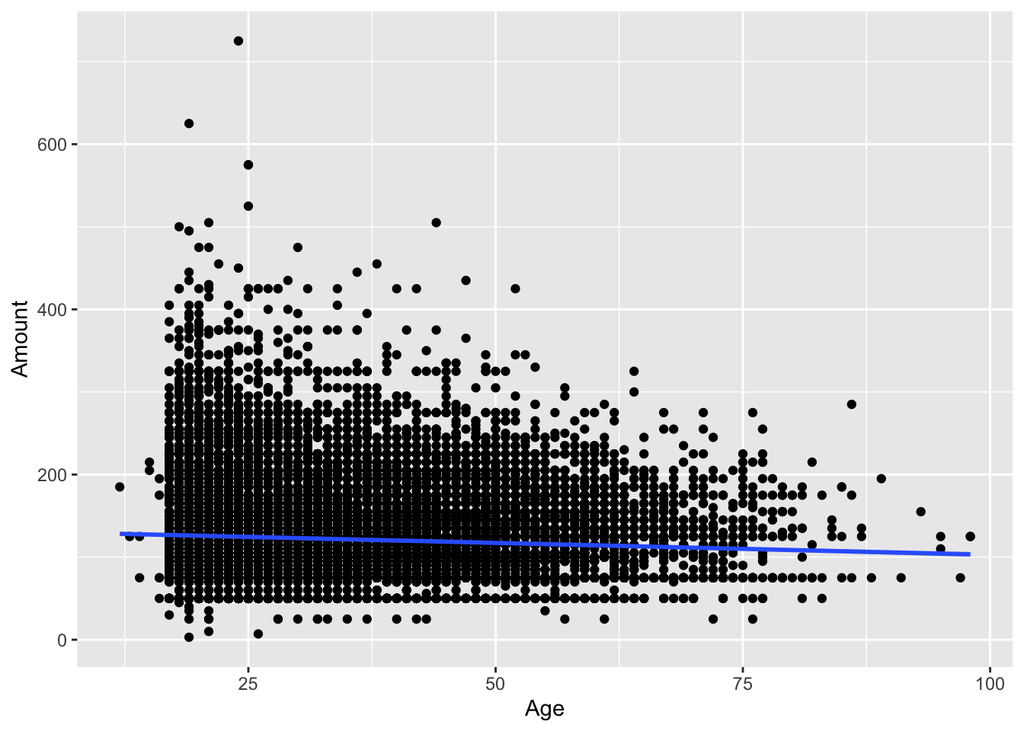

```r
p1 <- ggplot(data = speed, aes(x = Age, y = Amount))+
  geom_point()+
  geom_smooth(method="lm")
p1
```

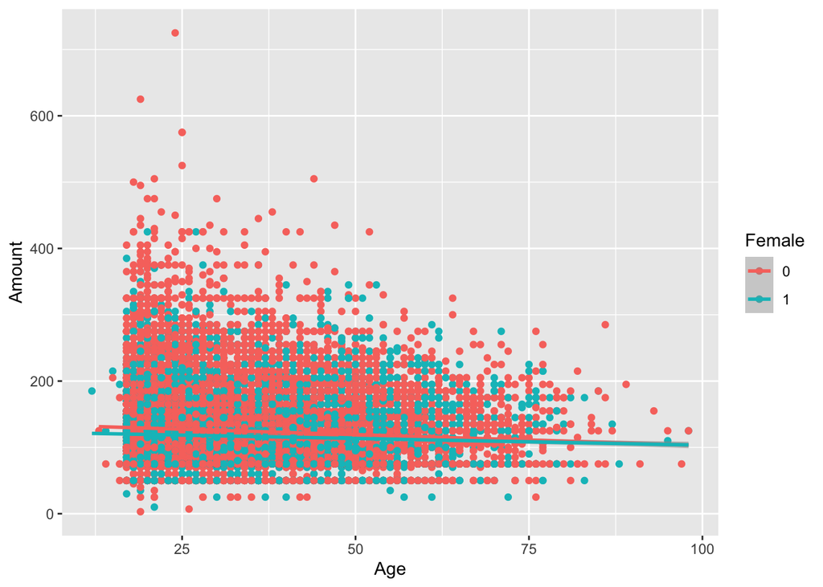

```r
p2<-ggplot(data = speed, aes(x = Age, y = Amount, color = Female))+
  geom_point()+
  geom_smooth(method="lm")
p2
```

### Part G

Add a final facet layer to the plot make two different sub-plots by Sex with `facet_wrap( ~ Female)`.

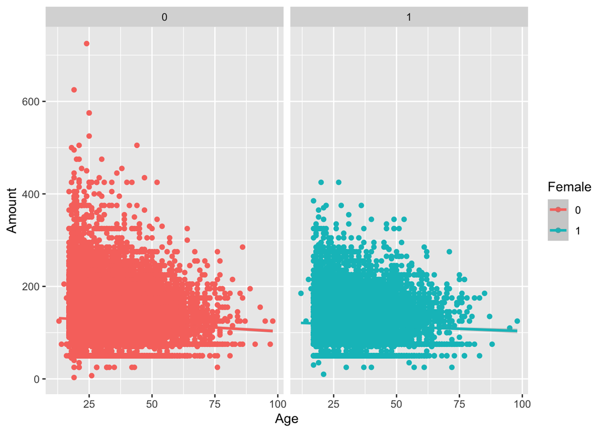

```r
p2 + facet_wrap(~Female)
```

## Question 9

Now let’s look at the possible interaction between Sex (`Male` or `Female`) and whether a driver is from In-State or Out-of-State (`OutState`).

### Part A

Use `R` to examine the data and find the mean for (i) Males In-State, (ii) Males Out-of-State, (iii) Females In-State, and (iv) Females Out-of-State.

```r
# Summarize for Men in State

speed %>%
  filter(Female == 0,
         OutState == 0) %>%
  summarize(mean = mean(Amount))
```

| mean |
| --- |
| 124 |

```r
# Summarize for Men Out of State

speed %>%
  filter(Female == 0,
         OutState == 1) %>%
  summarize(mean = mean(Amount))
```

| mean |
| --- |
| 128 |

```r
# Summarize for Women in State

speed %>%
  filter(Female == 1,
         OutState == 0) %>%
  summarize(mean = mean(Amount))
```

| mean |
| --- |
| 115 |

```r
# Summarize for Women Out of State

speed %>%
  filter(Female == 1,
         OutState == 1) %>%
  summarize(mean = mean(Amount))
```

| mean |
| --- |
| 124 |

### Part B

Now run a regression of the following model:

$$\text{Amount}_i=\hat{\beta_0}+\hat{\beta_1}Female_i+\hat{\beta_2}OutState_i+\hat{\beta_3}Female_i*OutState_i$$

```r
sex_state_reg <- lm(Amount ~ Female + Female:OutState, data = speed)
summary(sex_state_reg)
```

```
##
## Call:
## lm(formula = Amount ~ Female + Female:OutState, data = speed)
##
## Residuals:
##     Min      1Q  Median      3Q     Max
## -120.68  -48.68   -8.68   31.32  601.32
##
## Coefficients:
##                   Estimate Std. Error t value Pr(>|t|)
## (Intercept)       123.6775     0.4391 281.650  < 2e-16 ***
## Female1            -8.8790     0.7541 -11.775  < 2e-16 ***
## Female0:OutState1   4.2915     0.9152   4.689 2.76e-06 ***
## Female1:OutState1   9.4672     1.3586   6.968 3.27e-12 ***
## ---
## Signif. codes:  0 '***' 0.001 '**' 0.01 '*' 0.05 '.' 0.1 ' ' 1
##
## Residual standard error: 56.06 on 31670 degrees of freedom
## Multiple R-squared:  0.006629,   Adjusted R-squared:  0.006535
## F-statistic: 70.44 on 3 and 31670 DF,  p-value: < 2.2e-16
```

```r
tidy(sex_state_reg)
```

| term | estimate | std.error | statistic | p.value |
| --- | --- | --- | --- | --- |
| (Intercept) | 124 | 0.439 | 282 | 0 |
| Female1 | -8.88 | 0.754 | -11.8 | 6.14e-32 |
| Female0:OutState1 | 4.29 | 0.915 | 4.69 | 2.76e-06 |
| Female1:OutState1 | 9.47 | 1.36 | 6.97 | 3.27e-12 |

### Part C

Write out the estimated regression equation.

$$\widehat{Amount}_i=123.68-8.88 \, Female_i+4.29 \, OutState_i+5.17 \, (Female_i\times OutState_i)$$

```r
# PUT CODE HERE
```

### Part D

What does each coefficient mean?

- $\hat{\beta_0}= \$123.68$; mean for in-state males
- $\hat{\beta_1}=-\$8.88$: difference between in-state males and females
- $\hat{\beta_2}=\$4.29$: difference between males in-state vs. out-of-state
- $\hat{\beta_3}=\$5.17$: difference between effect of being in-state vs. out-of-state between males vs. females (or, equivalently, difference between effect of being male vs. female between in-state vs. out-of-state)

```r
# PUT CODE HERE
```

### Part E

Using the regression equation, what are the means for

- 1. Males In-State
- 2. Males Out-of-State
- 3. Females In-State
- 4. Females Out-of-State?

Compare to your answers in part A.

- Males In-State: $\hat{\beta_0}=\$123.68$
- Males Out-of-State: $\hat{\beta_0}+\hat{\beta_2}=123.68+4.29=\$127.97$
- Females In-State: $\hat{\beta_0}+\hat{\beta_1}=123.68-8.88=\$114.80$
- Females Out-of-State: $\hat{\beta_0}+\hat{\beta_1}+\hat{\beta_2}+\hat{\beta_3}=123.68-8.88+4.29+5.17=\$124.26$

```r
# PUT CODE HERE
```

## Question 10

Collect your regressions from questions 5, 6b, 8a, 8b, and 9b and output them in a regression table with `huxtable()`.

```r
library(huxtable)
huxreg(female_reg, male_reg, age_reg, interact_reg, sex_state_reg) # the default
```

|  | (1) | (2) | (3) | (4) | (5) |
| --- | --- | --- | --- | --- | --- |
| (Intercept) | 124.665 *** | 116.726 *** | 134.200 *** | 135.546 *** | 123.678 *** |
|  | (0.386) | (0.548) | (0.910) | (1.074) | (0.439) |
| Female1 | -7.939 *** |  | -7.852 *** | -12.023 *** | -8.879 *** |
|  | (0.670) |  | (0.668) | (1.893) | (0.754) |
| Male |  | 7.939 *** |  |  |  |
|  |  | (0.670) |  |  |  |
| Age |  |  | -0.286 *** | -0.326 *** |  |
|  |  |  | (0.025) | (0.030) |  |
| Age:Female1 |  |  |  | 0.124 * |  |
|  |  |  |  | (0.053) |  |
| Female0:OutState1 |  |  |  |  | 4.291 *** |
|  |  |  |  |  | (0.915) |
| Female1:OutState1 |  |  |  |  | 9.467 *** |
|  |  |  |  |  | (1.359) |
| N | 31674 | 31674 | 31674 | 31674 | 31674 |
| R2 | 0.004 | 0.004 | 0.009 | 0.009 | 0.007 |
| logLik | -172510.224 | -172510.224 | -172443.461 | -172440.687 | -172474.987 |
| AIC | 345026.449 | 345026.449 | 344894.922 | 344891.373 | 344959.974 |
| *** p < 0.001; ** p < 0.01; * p < 0.05. |  |  |  |  |  |

```r
# let's customize a bit
huxreg(female_reg,
       male_reg,
       age_reg,
       interact_reg,
       sex_state_reg,
       coefs = c("Constant" = "(Intercept)",
                 "Female" = "Female1",
                 "Male" = "Male",
                 "Age" = "Age",
                 "Age*Female" = "Age:Female1",
                 "Out of State" = "Female0:OutState1",
                 "Female*Out of State" = "Female1:OutState1"),
       statistics = c("N" = "nobs",
                      "R-Squared" = "r.squared",
                      "SER" = "sigma"),
       number_format = 2)
```

|  | (1) | (2) | (3) | (4) | (5) |
| --- | --- | --- | --- | --- | --- |
| Constant | 124.67 *** | 116.73 *** | 134.20 *** | 135.55 *** | 123.68 *** |
|  | (0.39) | (0.55) | (0.91) | (1.07) | (0.44) |
| Female | -7.94 *** |  | -7.85 *** | -12.02 *** | -8.88 *** |
|  | (0.67) |  | (0.67) | (1.89) | (0.75) |
| Male |  | 7.94 *** |  |  |  |
|  |  | (0.67) |  |  |  |
| Age |  |  | -0.29 *** | -0.33 *** |  |
|  |  |  | (0.02) | (0.03) |  |
| Age*Female |  |  |  | 0.12 * |  |
|  |  |  |  | (0.05) |  |
| Out of State |  |  |  |  | 4.29 *** |
|  |  |  |  |  | (0.92) |
| Female*Out of State |  |  |  |  | 9.47 *** |
|  |  |  |  |  | (1.36) |
| N | 31674 | 31674 | 31674 | 31674 | 31674 |
| R-Squared | 0.00 | 0.00 | 0.01 | 0.01 | 0.01 |
| SER | 56.12 | 56.12 | 56.00 | 56.00 | 56.06 |
| *** p < 0.001; ** p < 0.01; * p < 0.05. |  |  |  |  |  |